# Anotación celular

```r
write.csv(anotacion, file.path(dir_res, "clase3_anotacion_por_cluster.csv"),
          row.names = FALSE)

# Mismo cuidado que en la sección 3.1: `factor()` NO borra los nombres, así que
# hay que renombrar por célula antes de asignar a la metadata.
id_cl <- as.character(pbmc$clusters)
pbmc$tipo_celular <- setNames(factor(etiquetas[id_cl], levels = unique(etiquetas)),
                              colnames(pbmc))
pbmc$cl_ontologia <- setNames(unname(cl_ontologia[etiquetas[id_cl]]), colnames(pbmc))
pbmc$confianza_anotacion <- setNames(
  resumen$confianza[match(id_cl, resumen$cluster)], colnames(pbmc))
table(pbmc$tipo_celular)
```

```
#>
#>   Monocito CD14+    T CD4 memoria      T CD4 naive               NK
#>             1694             1184             1124              742
#>    T CD8 memoria      T CD8 naive             MAIT          B naive
#>              446              419              403              314
#>        B memoria    NK CD56bright   Monocito CD16+  DC convencional
#>              200              142               88               88
#>     Plasmablasto DC plasmacitoide      Sin asignar
#>               35               23                5
```

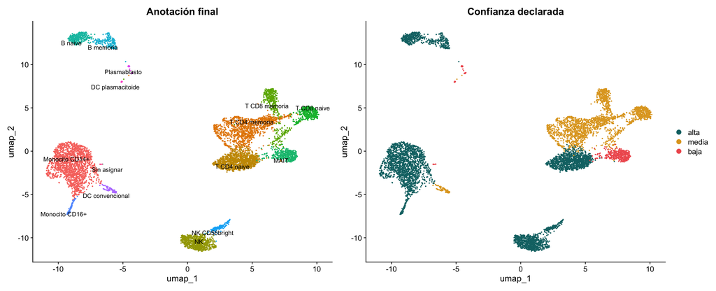

```r
# Los mismos colores que en las diapositivas de la clase
COL_CONF <- c(alta = "#0F7173", media = "#E0A526", baja = "#F05D5E")

(DimPlot(pbmc, group.by = "tipo_celular", label = TRUE, repel = TRUE,
         label.size = 3.5) + ggtitle("Anotación final") + NoLegend()) |
(DimPlot(pbmc, group.by = "confianza_anotacion", cols = COL_CONF) +
   ggtitle("Confianza declarada"))
```

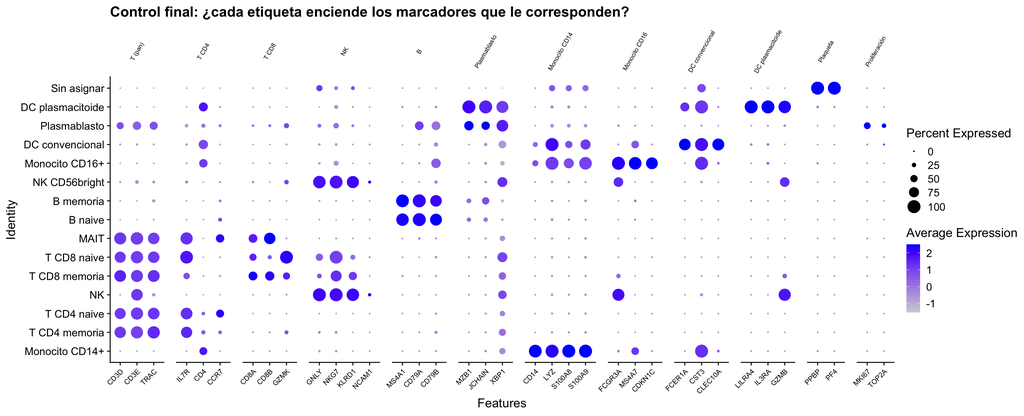

```r
# Verificación: los marcadores canónicos deben ser coherentes con las etiquetas
DotPlot(pbmc, features = marcadores_canonicos, group.by = "tipo_celular") +
  RotatedAxis() +
  theme(axis.text.x = element_text(size = 8), strip.text = element_text(size = 7, angle = 60)) +
  labs(title = "Control final: ¿cada etiqueta enciende los marcadores que le corresponden?")
```

```r
saveRDS(pbmc, ck3)
tam_archivo(ck3)
```

```
#> results/clase3_pbmc_anotado.rds - 262.9 MB
```

## 8. Síntesis

1. **La anotación es una hipótesis**, no un resultado. Se sostiene con evidencia convergente.
2. **Los marcadores canónicos vienen de la proteína**; el ARNm es un proxy imperfecto (dropout, ARNm ≠ proteína, expresión compartida).
3. **`celldex` cambió de API**: `fetchReference(nombre, versión)`. Las referencias ahora están versionadas y mapeadas a Cell Ontology.
4. **Nunca mires solo la etiqueta**: score, delta y `pruned.labels` son parte del resultado. Un `NA` es información.
5. **Anota por célula y por cluster.** Donde no coinciden, hay algo que entender.
6. **El RNA ambiental produce anotaciones falsas.** Diagnostica siempre; corrige con cuidado y compara.
7. **Declara la confianza con una regla explícita.** “Baja” no es “incorrecta”: es donde los métodos no convergen y la etiqueta depende de tu criterio.
8. **Usa vocabulario controlado** (Cell Ontology) para que tu anotación sirva más allá de tu propio análisis.

El jueves agregamos una modalidad que ataca directamente el punto 2: **medir la proteína de superficie en las mismas células**.